# Report

## Clustermap

### Boxplot Log2 Unnormalized

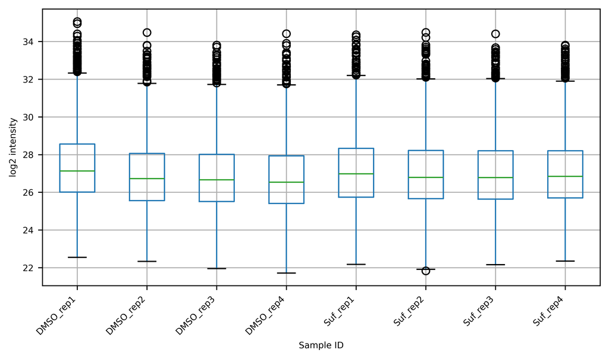

### Clustermap Ward

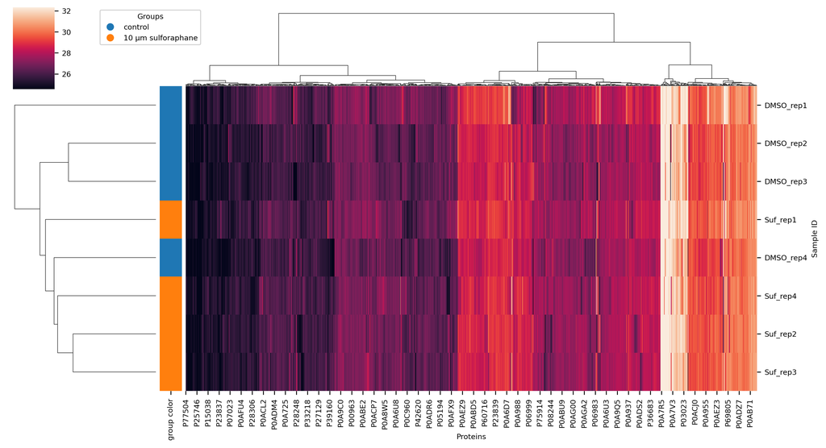

### Clustermap Ward Median

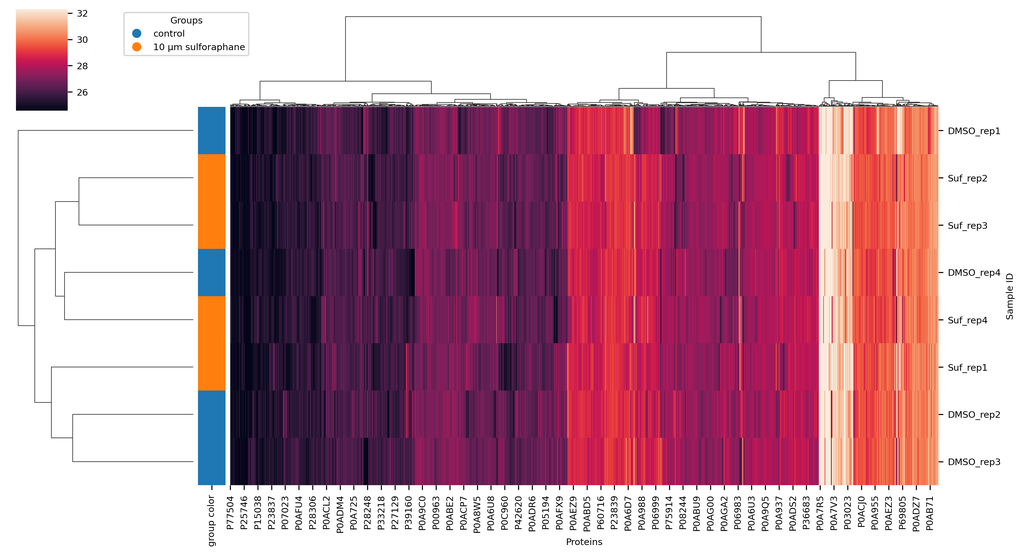

### Cv Vs Mean

[interactive chart not shown]

## Completeness

### Data Completeness Bar Plot

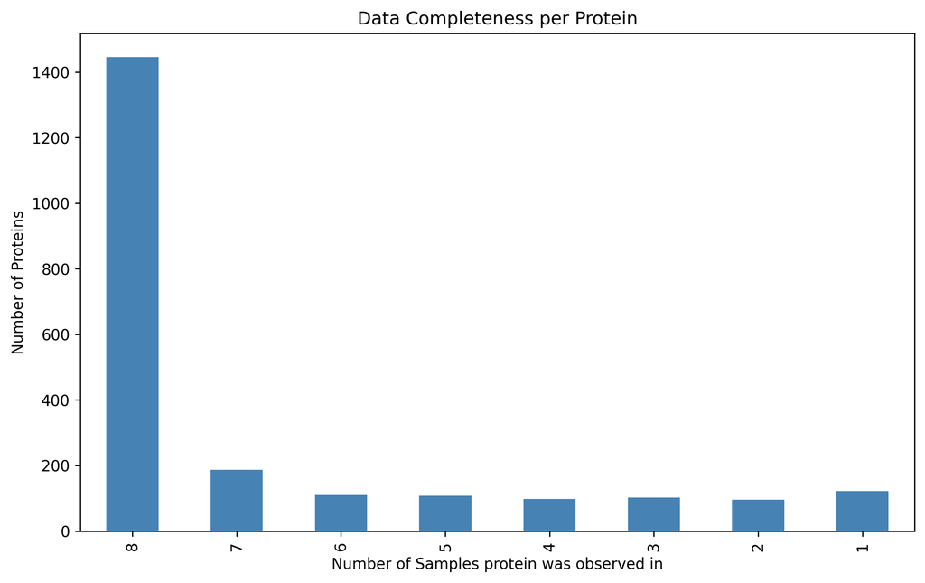

### Data Completeness Step Plot

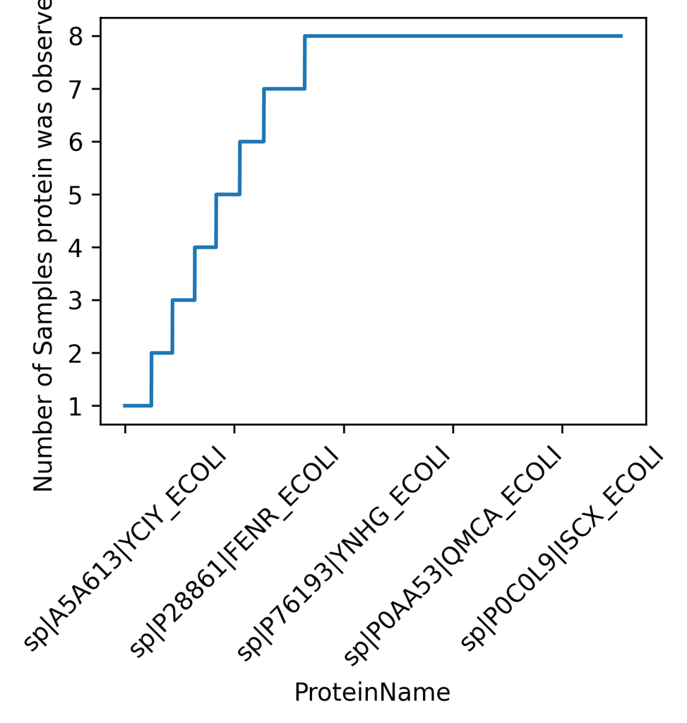

### Proteins

[figure not shown]

Loading ITables v2.8.0 from the `init_notebook_mode` cell... (need [help](https://mwouts.github.io/itables/troubleshooting.html)?)

### Proteins Identifiers

[figure not shown]

Loading ITables v2.8.0 from the `init_notebook_mode` cell... (need [help](https://mwouts.github.io/itables/troubleshooting.html)?)

# Differential Regulation

Find differently expressed proteins between the control and the 10 µm sulforaphane condition.

## Overview Differential Regulation

### Volcano Plot

[interactive chart not shown]

### Differential Regulation

[figure not shown]

Loading ITables v2.8.0 from the `init_notebook_mode` cell... (need [help](https://mwouts.github.io/itables/troubleshooting.html)?)

### Differently Regulated As In Paper

[figure not shown]

Loading ITables v2.8.0 from the `init_notebook_mode` cell... (need [help](https://mwouts.github.io/itables/troubleshooting.html)?)

### Highlighted Proteins In Figure3

[figure not shown]

Loading ITables v2.8.0 from the `init_notebook_mode` cell... (need [help](https://mwouts.github.io/itables/troubleshooting.html)?)

### Data Completeness Per Group Median

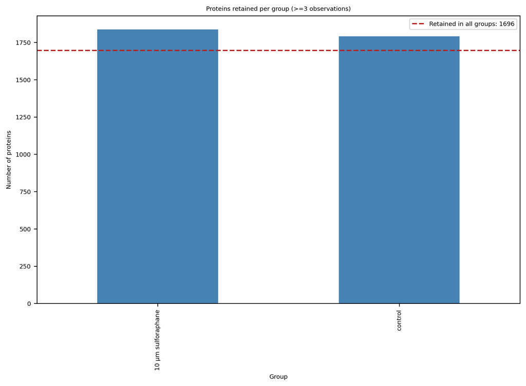

# Maltose Uptake

Analyze the maltose uptake pathway.

## Overview Maltose Uptake

### Volcano Plot

[interactive chart not shown]

### Differential Regulation

[figure not shown]

Loading ITables v2.8.0 from the `init_notebook_mode` cell... (need [help](https://mwouts.github.io/itables/troubleshooting.html)?)

### Differently Regulated As In Paper

[figure not shown]

Loading ITables v2.8.0 from the `init_notebook_mode` cell... (need [help](https://mwouts.github.io/itables/troubleshooting.html)?)

### Highlighted Proteins In Figure3

[figure not shown]

Loading ITables v2.8.0 from the `init_notebook_mode` cell... (need [help](https://mwouts.github.io/itables/troubleshooting.html)?)

### Highlighted Proteins In Figure3 Intensities

[figure not shown]

Loading ITables v2.8.0 from the `init_notebook_mode` cell... (need [help](https://mwouts.github.io/itables/troubleshooting.html)?)

# Uniprot Annotations

## Overview Uniprot Annotations

### Differently Regulated As In Paper

[figure not shown]

Loading ITables v2.8.0 from the `init_notebook_mode` cell... (need [help](https://mwouts.github.io/itables/troubleshooting.html)?)

### Highlighted Proteins In Figure3

[figure not shown]

Loading ITables v2.8.0 from the `init_notebook_mode` cell... (need [help](https://mwouts.github.io/itables/troubleshooting.html)?)

### Highlighted Proteins In Figure3 Intensities

[figure not shown]

Loading ITables v2.8.0 from the `init_notebook_mode` cell... (need [help](https://mwouts.github.io/itables/troubleshooting.html)?)

### Highlighted Proteins In Figure3 Intensities Normalized

[figure not shown]

Loading ITables v2.8.0 from the `init_notebook_mode` cell... (need [help](https://mwouts.github.io/itables/troubleshooting.html)?)

### Annotations

[figure not shown]

Loading ITables v2.8.0 from the `init_notebook_mode` cell... (need [help](https://mwouts.github.io/itables/troubleshooting.html)?)

### Enrichment Analysis

[interactive chart not shown]